# Analysis of MST-41 Anti-Fibrotic Therapy

Peter Higgins

# Anti-fibrotic Therapy Data

## Background

- Intestinal Fibrosis leads to surgery in 70% of Crohn’s disease
- Intestinal Myofibroblasts are stimulated to generate scar by:
  - injury/ wounding
  - matrix stiffness

## Background 2

- Matrix Stiffness Activates Myofibroblasts
- Activated Myofibroblasts Synthesize Stiff Matrix
- Positive Feedback Loop –> **More Fibrosis**
  - This is Bad
    - It gets worse
      - It can get *even* worse

## Hypothesis and Aims

### Hypothesis

- Determine whether Anti-fibrotic drug can reverse fibrosis

# Experimental Design

## Experimental Design 1

- Get mice
- Strep cleanout

## Experimental Design 2

1. Infect with Salmonella
2. Wait 8 days
3. Levo x 5 days in the water
4. Rest Day
5. Anti-fibrotic drug x 10 days
6. Image
- Ultrasound + SWV + Strain
- Photoacoustic
7. Sac

# Results

## Weight Result

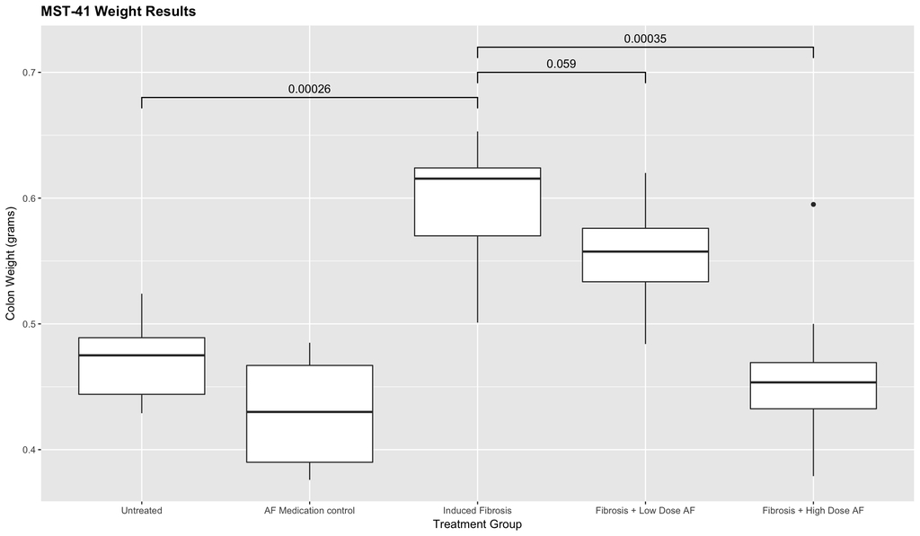

## TGFb Result

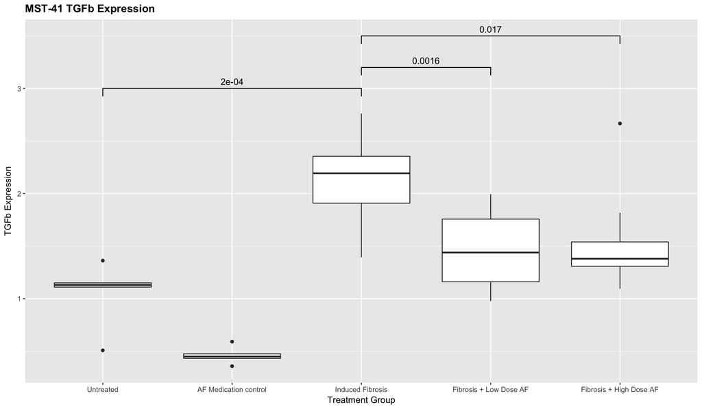

## CTGF Result

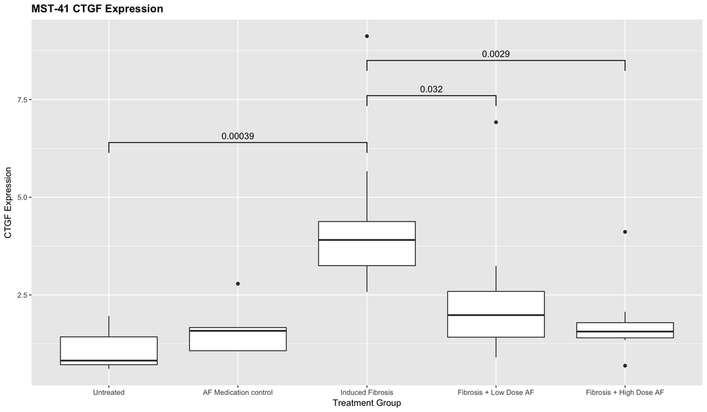

## IGF-1 Result

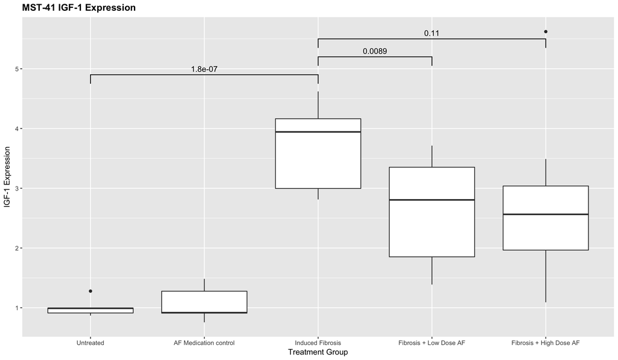

## Collagen 1 Result

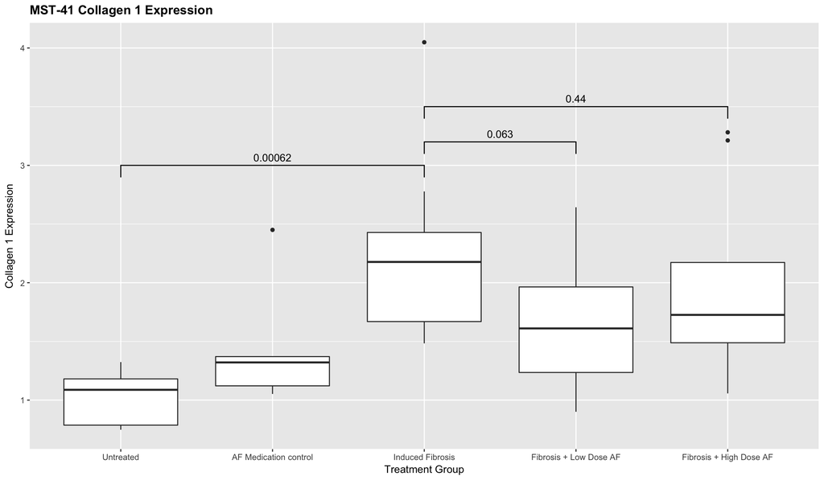

## Collagen 3 Result

[figure not shown]

# Conclusions

# Examples of other stuff you can do with Rmd

## Block Quotes

A friend once said:

> It’s always better to give than to receive. Totes magotes, my friend, he said. I don’t know why he said this.

## Including Plots

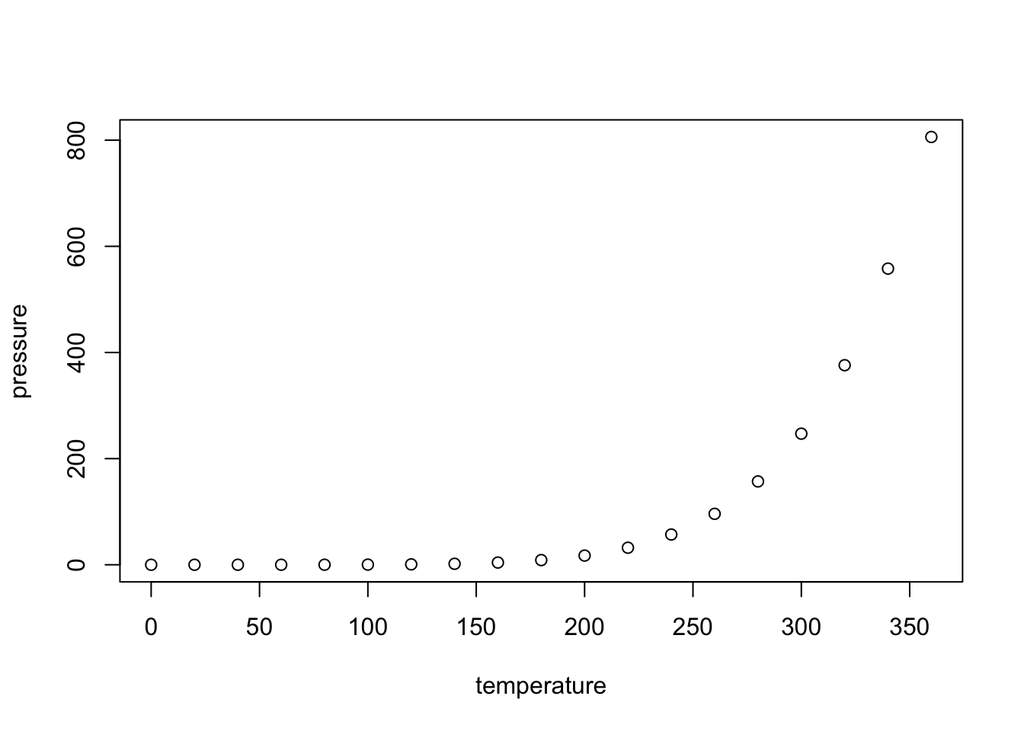

## And Tables

[output not shown]

## Inline R code

Inline R Code

There were 50 cars studied

## R Code Chunks

```r
summary(cars$dist)
```

```
##    Min. 1st Qu.  Median    Mean 3rd Qu.    Max.
##    2.00   26.00   36.00   42.98   56.00  120.00
```

```r
summary(cars$speed)
```

```
##    Min. 1st Qu.  Median    Mean 3rd Qu.    Max.
##     4.0    12.0    15.0    15.4    19.0    25.0
```

## Add Links

Links

## Miscellaneous

- Manual Line breaks,  
  end line with 2 or more spaces  
  Roses are red,  
  Violets are blue.

superscript<sup>2</sup>

strikethrough

## Horizontal Line break

Horizontal Rule / Page Break

Three or more asterisks or dashes:

and continue

## Use of the echo parameter

- If you want to see the R code **and** the output, like in the previous summary table, then set the parameter to `echo=TRUE`